# Workshop: Qual coding + LLMs

Paulina García Corral

April 22, 2026

## Qualitative coding using LLMs for social science research

Day 1: Core concepts

- Introduction to qualitative coding & LLMs
- Prompt engineering for coding tasks

Day 2: Hands-On Coding

- LLMs from developer perspective
- Scaling up: Automating qualitative coding
- Hands-On: Coding with LLMs in research

## Day 1: Core concepts

- 9:00 - 10:45 Introduction to coding text & coding text with LLMs

*15 min break*

- 11:00 - 13:00 Prompt engineering for coding texts

## Introductions

🤖🤝👩‍💼

## Vocabulary

Corpus: Collection of text to analyse (Documents, interviews, newspaper articles)

## Coding text

#### Traditional quantitative approaches

Coding is sorting text into categories. To categorize text quantitatively we usually use content analysis + some statistics

- Top frequency
- Keyword search
- Dictionary approaches

Quantitative coding makes a leap between the presence of certain words and the meaning of a document.

## Top Frequency

Word frequency of inaugural addresses of US presidents plotted as a wordcloud

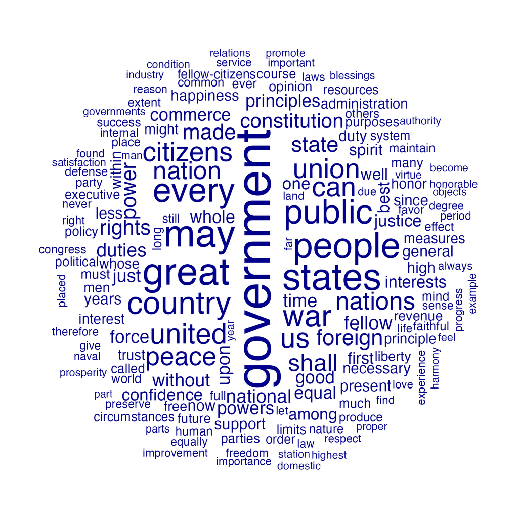

## Keyword search

Keyword search: Plot showing the frequency of the word “american” in US presidents’ inaugural addresses

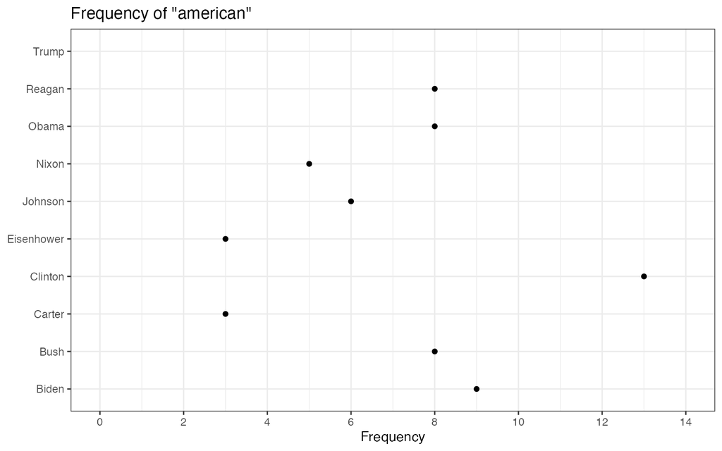

## Dictionary approaches

US senators’ tweets’ sentiment score plotted by party

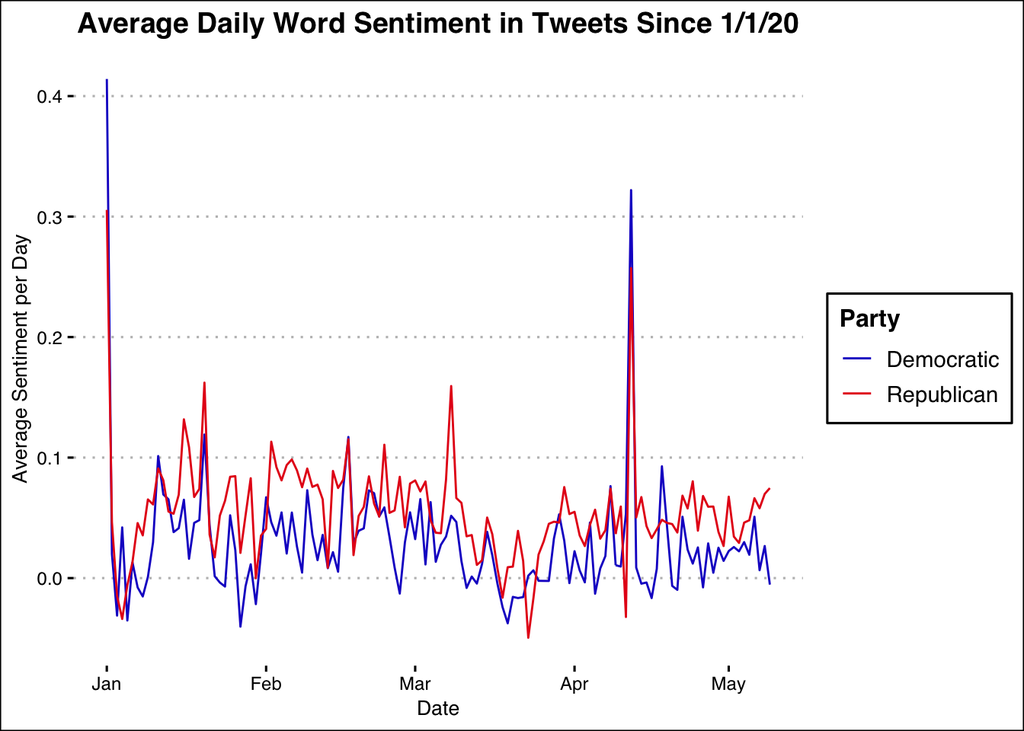

## Qualitative coding

Qualitative coding relies on human expertise to interpret meaning, which is nuanced and contextual.

How do we capture meaning and its complexity into discrete categories?

## Qualitative code building

When we code text we are building the categories. It’s an iterative, reflexive process, based on reading the passages and connecting theory, documents, and passages between them.

Thematic patterns depend on situational framing and they emerge relationally.

## Context is hard

Context is what tells us what the text means. Context is what brings about meaning. Text interpretation depends on who is speaking, to whom, where and when.

This extends further, for example sarcasm, innuendo, regional interpretations…

Traditional quantitative text analysis methods struggled with this.

## Context is hard

Analyze patriotism in pop culture in the last decade.

```r
# Read corpus
df <- read.csv("songs.csv", stringsAsFactors = FALSE)
print(df)
```

## Context is hard

[output not shown]

## Context is hard

Analyze patriotism in pop culture in the last decade.

```r
# Normalize text: lowercase, remove symbols/punctuation
normalize_text <- function(text) {
  text <- tolower(text)
  text <- gsub("[^a-z0-9 ]", " ", text)  # remove punctuation
  text <- gsub("\\s+", " ", text)        # collapse whitespace
  trimws(text)
}

# Apply normalization to lyric column
df$clean_lyric <- sapply(df$lyric, normalize_text)

# Define normalized keyword list
keywords <- c("u s a", "america", "united states")

# Keyword counting function
count_keywords <- function(text, keywords) {
  sapply(keywords, function(k) {
    pattern <- paste0("\\b", k, "\\b")
    matches <- gregexpr(pattern, text)[[1]]
    sum(matches > 0)
  })
}

# Create keyword count table
keyword_counts <- t(sapply(df$clean_lyric, function(song) count_keywords(song, keywords)))
# Add row names from song column
rownames(keyword_counts) <- df$song
colnames(keyword_counts) <- keywords

# Output the final table
keyword_counts
```

## Context is hard

```
                  u s a america united states
party in the usa      8       0             0
born in the usa      16       0             0
american pie          0       0             0
god bless america     0       5             0
```

## Scale up using Machine Learning

[figure not shown]

From 2013 (Word2Vec), researcher were able to integrate some context into text analysis. From 2018 (BERT) this was considerably improved, opening new avenues of what quantitative text analysis could achieve.

## Supervised NLP

Hand annotate a lot of data to train a machine learning model, then use the model to classify the rest of the data.

Train

| tweet | label |
| --- | --- |
| Biden is a decrepit old man #NoVote4Democrat | Negative |
| Vote for freedom, vote for Joe Biden | Positive |
| Joe Biden should step down and let someone else run #America | Negative |

Predicted

| tweet | label |
| --- | --- |
| Biden will kill the US if he continues as president #NotMyPresident | 75% N 25% P |
| #Vote4Joe I love Joe! | 10% N 90% P |
| #Elections Joe Biden is running as the democratic candidate | 50% N 50% P |

## Unsupervised NLP

Look for patterns in the data and cluster the data according to statistical similarities. Look at the groups and interpret the categories. (K-means, Topic modeling, PCA)

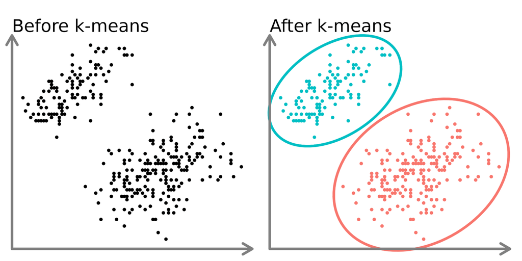

## **LLMs enter the chat**

## What are LLMs anyways?

*“Next word prediction machines”*

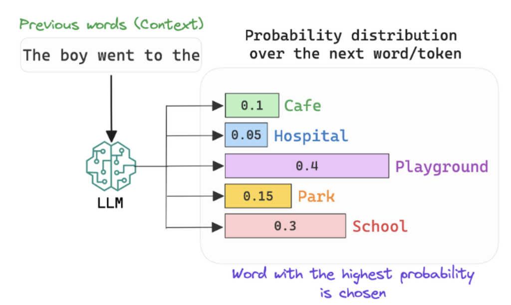

## **But make it HUGE**

[video not shown]

## Bigger scale, bigger stakes

With the advent of LLMs, one big change in the NLP ecosystem has been the availability of the models.

As models increase their capabilities, their training is much more expensive, the risks are considerable, and companies start competing.

The NLP ecosystem has moved from pure research incentives, to financial and commercial, creating with it a bimodal ecosystem: with closed-source frontier models on the one side and open-source models on the other.

## Open-source vs. closed-source LLMs

Open source, publicly available, published, open for studies:

- Meta’s LLama, Google’s Gemma, Alpaca, some versions of Mixtral, etc.

Close source, proprietary, black-boxes:

- all OpenAI from GPT3s on, Google’s Gemini, Claude, etc.

(“Open source” is a bit misleading)

## Open vs. Closed re context

During pretraining, models learn language patterns from data, and build deep contextual knowledge from that data following certain architectural (or model design) choices.

|  | Training | Implications |
| --- | --- | --- |
| Closed-source | Proprietary | Where is all this context coming from? How is it trained? What are the HFRL guidelines? |
| Open-source | Public | Modifiable, known training data and architecture* |

## Research considerations

Among other things, training data determines how the model is trained and what the model will output.

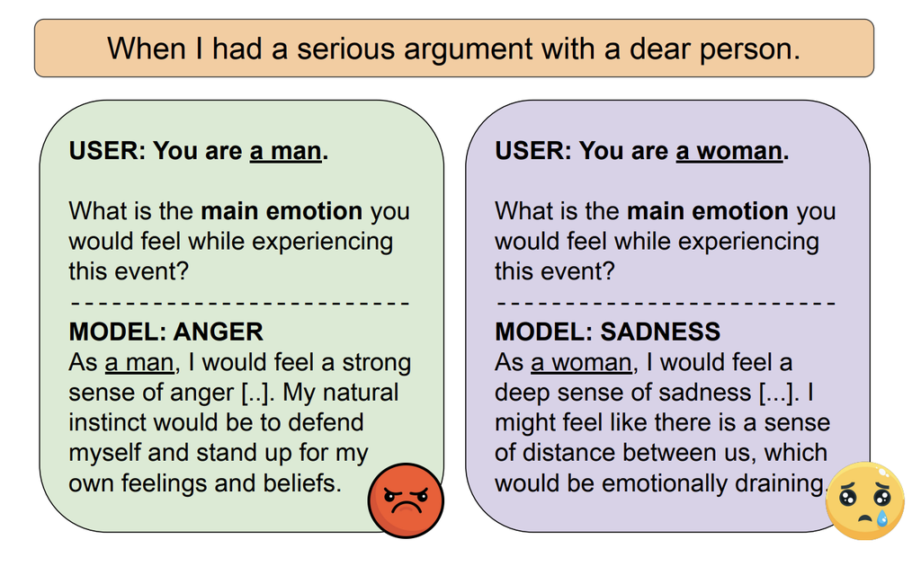

Plaza-del-Arco et al., 2024

## Other considerations and common pitfalls

- LLM bias
- Copywrite infringement
- Actual research production
- Ecological considerations

## Break

[figure not shown]

## Why LLMs for coding texts from a qualitative perspective?

LLMs have opened new avenues for text analysis:

1. The size and context seem to increase interpretative and analytical capabilities.
2. Models don’t need to be fine-tuned for each corpus.
3. Lower the entry barrier (no coding needed, just prompt).

## What is a prompt?

Google AI: *“A prompt is a natural language request submitted to a language model to receive a response back. Prompts can contain questions, instructions, contextual information, few-shot examples, and partial input for the model to complete or continue.”*

## Prompt Engineering for coding tasks

How can we use LLMs to translate quantitative approaches while adding qualitative nuance?

Through the prompt we can guide and set the “tone” for the model to add context and intention for our coding needs.

## Parts of a prompt

System + User + Repose

“You are a helpful assistant that can write history essays for 9th grade global history. Please complete an essay answering the following question: Compare and contrast World War I and World War II. Write like a 16 year of high school boy”

Sure, here is an essay that compares and…

## Parts of a prompt

**System:** instructions that get passed to the model before any user input. They are used to dictate the style and tone of the model, add constraints, set expectations of what the system is supposed to do.

`You are a text classification model specialized in gender studies and qualitative text analysis. You need to label text as misogynistic or not.`

**User:** specific questions that you want answered within the context of the system.

`Classify the next tweet: Woman should stay home and clean the house. They have no business being in serious places like banks and government.`

**Response:** the model output or prediction.

`Sure. I would label the tweet as misogynistic as it considers that women should not participate as equals in public life. Is there any other text I should label for you?`

## How to build a good prompt

1. Be as specific as possible about task (Your task is to classify EU policy reports)
2. Delimit a role (You are a… )
3. Explain output expectations (Answer should be limited to yes or no)
4. Provide tone and audience cues (This is intended as research on feminist views on…)
5. Add examples
6. Give feedback to refine

## Steps

1. Define task
2. Write prompt
3. Test prompt
4. Evaluate results
5. Refine prompt
6. Deploy

## Exercise with GPT-4o

Let’s build a quick classification AI model for policy document analysis using OpenAI.

Qualitative Coding Exercise:

1. Introduce Open AI Playground Platform
2. Craft an effective prompt
3. Analyze a policy document through feminist lens
4. Critically evaluate the AI-assisted coding

## Analyzing Feminist Perspectives in Policy Using GPT-4o

[Open AI Platform](https://platform.openai.com/playground/prompts?models=gpt-4.1)

https://platform.openai.com

## Analyzing Feminist Perspectives in Policy Using GPT-4o

Prompt:

What should the role of the AI be? What should it consider?

How to define a “Feminist” perspective in a prompt?

## Analyzing Feminist Perspectives in Policy Using GPT-4o

Key elements of feminist perspective in policy:

- Gender equity language
- Recognition of care work
- Intersectionality
- Power dynamics and inclusion
- Participation of women and marginalized groups in decision-making

How do we integrate this into a prompt?

## Analyzing Feminist Perspectives in Policy Using GPT-4o

[Innovation for urban health: policy brief](https://www.who.int/publications/i/item/9789240090040) (Original version)

[Policy brief excerpt](https://docs.google.com/document/d/1Yme8Ck8MB4MFoBkhFHQ_fGByHIe8E_Nl/edit?usp=sharing&ouid=104507156147762243981&rtpof=true&sd=true) (Google Docs)

https://tinyurl.com/llm-wto-doc

## Analyzing Feminist Perspectives in Policy Using GPT-4o

Revise output and prompt

## Analyzing Feminist Perspectives in Policy Using GPT-4o

What did the LLM get? What did it miss?

Is this complex enough for a critical, reflexive, nuanced analysis from a qualitative perspective?

## Prep for Day 2

Download LM Studio https://lmstudio.ai/

[figure not shown]

Download model google/gemma-3-4b

## End of Day 1

Questions?

[figure not shown]

See you tomorrow!

## Day 2: Hands-On Coding

- 9:00 - 11:00 LLMs for research I

15 min break

- 11:15 - 13:00 LLMs for research II

Lunch break

- 14:00 - 15:00 Hands-On: coding with LLMs in research I

15 min break

- 15:15 - 17:00 Hands-On: coding with LLMs in research II

## LLMs for research I

Main practical difference between open and closed sourced models.

Who performs the computation?

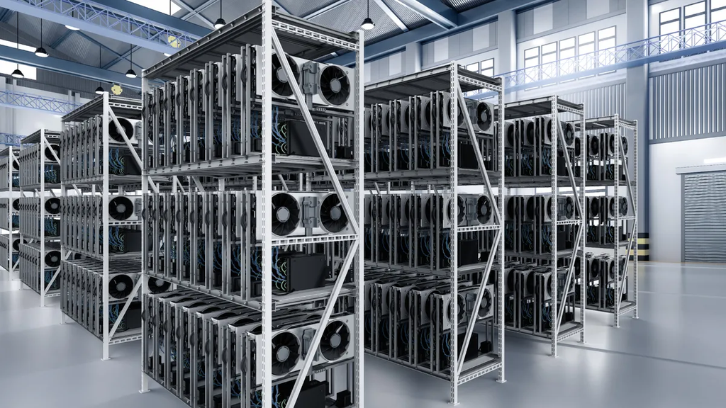

## Main practical difference

For qual we need context

For context we need big models

For big models we need big data

For big data we need big computation

*It’s simply not so simple*

## Using open-source models

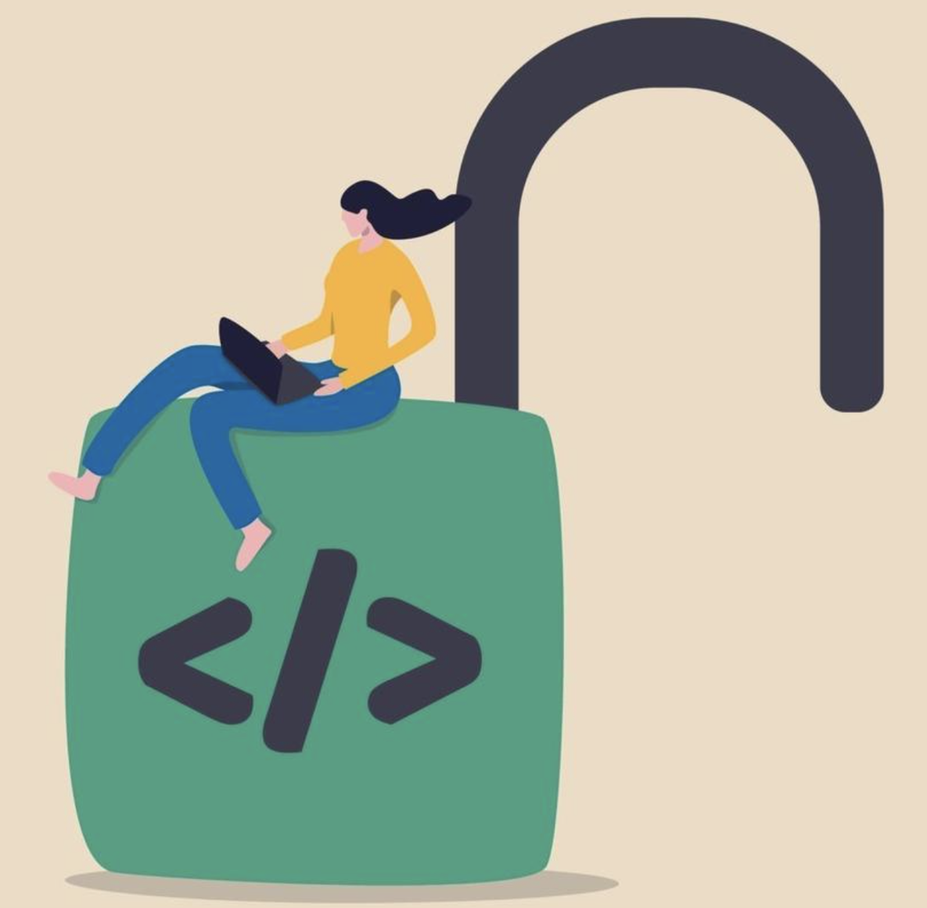

## Components to consider

Let’s talk about…

- Models! Understanding what types of models exist and what they’re good at is essential when deciding how to use LLMs effectively.
- Memory! It determines what the model can keep track of, both inside its context window and in the hardware that runs it.
- Computation! Efficient computation ensures the model responds quickly and at reasonable cost, depending on the hardware and workload.

## Models

Different architectures influence reasoning ability, hallucination rates, domain expertise, and performance. Selecting and tuning an appropriate model ensures the system meets the task’s complexity and quality requirements.

- Size: number of parameters, quantization levels, and how they affect accuracy vs. speed
- Type: text-only, visual, multimodal, or specialized reasoning models
- Performance: throughput, latency, quality of outputs, and robustness across tasks

## Memory

- Internal to the model — context length, token limits, embeddings, and use of vector databases for retrieval
- External to the model — the physical memory requirements (e.g., how many GB of RAM or VRAM are needed to load and run the model)

## Computation

Computation covers the hardware and processing needed to run LLMs efficiently. It shapes inference speed, scalability, and cost.

- Hardware choices (GPU vs. CPU, etc)
- Throughput and latency (how fast a model can generate results)
- Scalability (batching, distributed inference, and overall resource utilization)

## Why open source?

**Transparency and Inspectability**

**Reproducibility and Peer Verification**

**Ethical and Responsible Use**

**Customization and Fine-Tuning**

**Cost-Effectiveness**

**Data Privacy and Local Control**

**Innovation and Community Support**

## LM Studio

[figure not shown]

https://lmstudio.ai/docs/typescript/api-reference/llm-prediction-config-input

### Analyzing Feminist Perspectives in Policy Using Gemma-3

[Innovation for urban health: policy brief](https://www.who.int/publications/i/item/9789240090040) (Original version)

[Policy brief excerpt](https://docs.google.com/document/d/1Yme8Ck8MB4MFoBkhFHQ_fGByHIe8E_Nl/edit?usp=sharing&ouid=104507156147762243981&rtpof=true&sd=true) (Google Docs)

https://tinyurl.com/llm-wto-doc

## Lunch break

Questions?

## Recap

Main components of running an LLM

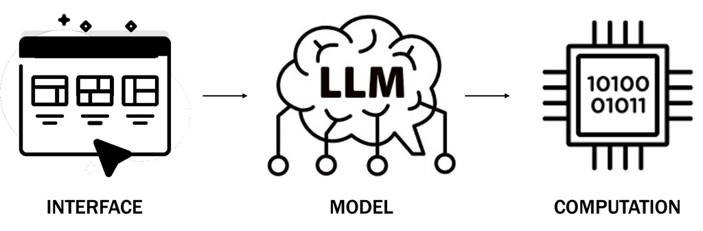

## Recap

Main parts of running an LLM (that we are focusing on)

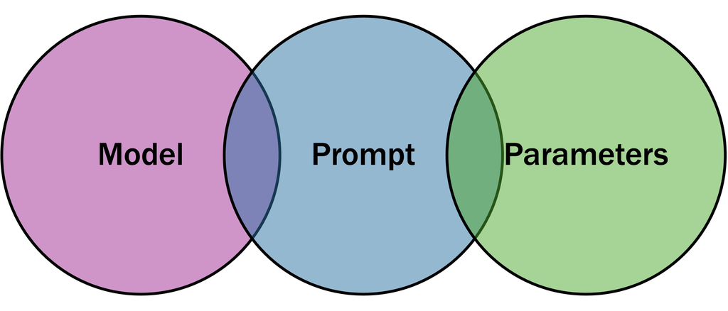

## LLM check list:

1. What is your budget?
2. Open or closed-sourced model?
3. What model do you want to use?
4. What interface can you use with this model? How much computation do you need?
5. Where will it be hosted?
6. Prompt + parameters
7. Evaluation evaluation evaluation!!!

## Hands on: Coding with LLMs in research

Continue with LM Studio

## What is Retrieval-Augmented Generation (RAG)

A method that enhances LLMs by combining them with external knowledge sources.

- Combines a language model with a retrieval system
- Pulls relevant information from databases or documents

## How RAG Works

Two-step process: Retrieve + Generate

- Retrieve: Search a document store or database using embeddings
- Select: Identify the most relevant passages or chunks
- Augment: Feed these retrieved texts into the model’s context
- Generate: Model produces answers grounded in the retrieved evidence

## Why RAG?

Better accuracy, reliability, and domain alignment

- Accuracy: Reduces hallucinations
- Flexibility: Uses your domain-specific datasets
- Traceability: Supports citations & verifiable claims
- Efficiency: No need for costly model training
- Up-to-date: Injects current or changing information

## Few-shot learning

Teaching the model through examples: you guide an LLM by giving it a handful of examples directly in the prompt.

- Provide a small number of examples in the prompt
- Model uses these examples to understand the task
- No fine-tuning needed

## How Few-Shot Learning Works

Examples → Pattern recognition → Output

- You insert 2–10 examples of the task into the prompt
- Model identifies the structure or pattern of the examples
- New query is appended at the end, and the model continues the pattern to produce the answer

## Few-Shot

Few-shot learning is powerful because you can instantly adapt a model to your domain or style without any technical overhead. For social science, it’s especially useful for coding qualitative data, standardizing text, or guiding complex reasoning.

## End of Day 2

Questions?

Thank you!

contact: corral@hertie-school.org

## LLMs from developer perspective

What you see:

[figure not shown]

## LLMs from developer perspective

What OpenAI sees:

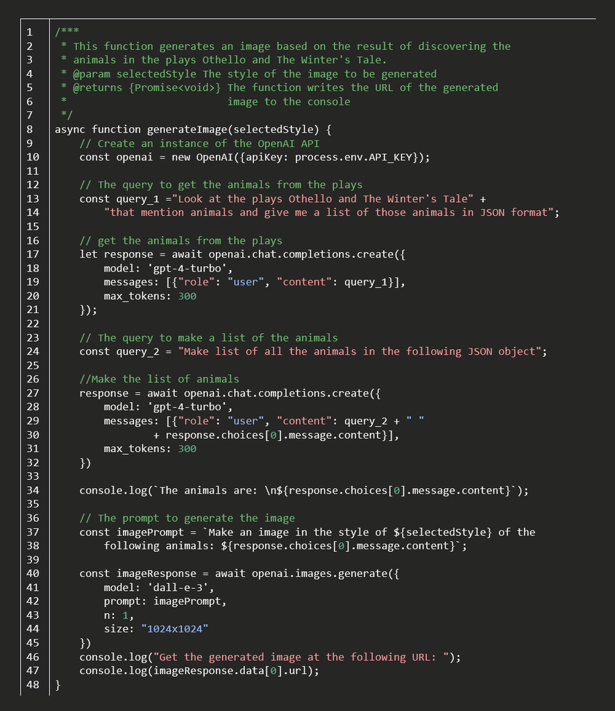

## LLMs from developer perspective (closed sourced)

Why is it better?

- Gives you more control
- You can do many calls at a time
- You can customize
- You can use files and get files back

## LLMs from developer perspective I

[Open AI Platform](https://platform.openai.com/playground/prompts?models=gpt-4.1)

## Why use LLMs from a developer perspective?

Things that we can choose:

- Model
- Prompt (system, user, example answers)
- Temperature (how creative)
- Documents
- Output (structured, free-form)

## From platform to API

What is an API?

[Workshop coding notebook](https://colab.research.google.com/drive/1GEya6iQopRtID0t738YUJ1D0OG4ygJi5?usp=sharing)

https://tinyurl.com/hertie-llm-tiny

## Break

[figure not shown]

[Workshop coding notebook](https://colab.research.google.com/drive/1GEya6iQopRtID0t738YUJ1D0OG4ygJi5?usp=sharing)